# SIT796: Reinforcement Learning

**Task 3.1D: Exact Policy Iteration Implementation for MDPs**

- Name: Bree McLennan
- Student ID: 400150369

**Overview**

During week 3, you have learnt about Markov Decision Processes. You have also been provided with an example of the implementation of Value Iteration in the workshop for the week.

In this task you need to implement the exact policy iteration method and test it in the environment you scoped in Task 1.1P. Your implementation should employ a linear system to find the exact solution for a policy that can achieve the goal. Your report, on the other hand, should refer to the relevant pseudocode in your Jupyter Notebook. You are also expected to show a graphical model similar to that used in Week 3 Practical corresponding to your state and transition probabilities. Also include the average reward result over 1000 steps.

To complete this assignment, you need to refer back to Week 1 lecture, Task 1.1P and Practical 3.

**Submission Details**

For this task you need to provide the code and a report on the implementation of the exact policy iteration that allows you to achieve the goal. You may use Practical 3 as the basis for the demonstration of your policy, but the environment itself has to be that you scoped in Task 1.1P. The implementation of the policy iteration method should be from scratch. To solve the actual linear system you may use NumPy.

The policy iteration should be demonstrated using a Jupiter notebook. The report and the Jupiter notebook need to be submitted to OnTrack. To do so, Convert the Jupyter Notebook to a PDF and append it to your report so as to submit that document. Also include a URL link to a GitHub repo containing the Notebook file and the environment implementation. You may have to install pandoc to convert a Jupyter Notebook to a PDF document: http://pandoc.org/installing.html

# 1. The CartPole game

As described in Task 1.1P, The Cart-Pole environment comprises of a pole stick with an un-actuated joint attached to a cart. It resembles an inverted pendulum with its centre of gravity above its pivot point. This cart-pole vehicle moves freely along a frictionless horizontal, one-dimensional track. The pole can move only rotationally on the vertical plane, relative to the cart and all movements of the cart and the pole are constrained by the laws of physics. The goal of this task is to prevent the pole from falling over by keeping the cart-pole balanced vertically by applying appropriate left (-1) and right (+1) forces to the pivot point. The episode ends when the pole reaches more than 15 degrees from vertical, or the cart moves horizontally more than 2.4 units from the centre of the environment.

This python notebook aims to solve the CartPole game using a simple linear approach and conclude with exploring the Markov Decision Process (MDP) for the CartPole game.

# 2. Environment Setup and Configuration

```python
# install required system dependencies
!{sys.executable} -m pip install gym #Install the gym environment
!pip install gym[box2d,atari] pyvirtualdisplay
!apt-get install -y xvfb x11-utils
!apt-get install x11-utils > /dev/null 2>&1
!pip install PyVirtualDisplay==2.0.* \
  PyOpenGL==3.1.* \
  PyOpenGL-accelerate==3.1.* \
  gym[box2d]==0.17.*
!pip install pyglet
!pip install mdp
```

[output not shown]

[output not shown]

```
     ━━━━━━━━━━━━━━━━━━━━━━━━━━━━━━━━━━━━━━ 454.9/454.9 KB 28.2 MB/s eta 0:00:00
```

```python
#Import key libraries to run the CartPole environment
import gym
import numpy as np
import matplotlib.pyplot as plt
from matplotlib import animation #for animating the solution
import cv2 #For plotting the MDP and exporting to .png image file
import time #for timings

#Libraries with useful helper functions
import sys
import pandas as pd
import random
import IPython
import base64
import io
import os
import pyvirtualdisplay

#Suppress any future warnings
import warnings
warnings.simplefilter(action='ignore', category=FutureWarning)

#For animating and visualising the solutions to the CartPole environment
from gym.wrappers import Monitor
from IPython import display
from IPython.display import HTML
from pyvirtualdisplay import Display

#For MDP library, functions and visualisation
from google.colab import drive
```

```python
#Start the Display capture for the solution
display = Display(visible=0, size=(1400, 900))
display.start()
```

```
<pyvirtualdisplay.display.Display at 0x7f5fd1319be0>
```

# 3. Initialise the CartPole Environment

To solve the cartpole balancing problem, the environment needs to be initialized. The CartPole environment has an:

**Observation or state space** which defines the structure of information received from the environment. In this context it will be

1. The position of the cart on the horizontal track. Positive value means 'right' position.
2. The cart's horizontal velocity. Positive means moving to the right.
3. The angle of the pole on the vertical axis. Positive means clock-wise.
4. The rate of rotation change (angular velocity) of the pole angle. Positive means rotating clock-wise.

These states will be technically represented as a 4-dimensional state such as x=(theta, y, theta_dot, y_dot). Where 'theta' is the angle of the pole, 'y' the position of the cart and 'theta_dot' & 'y_dot' are their respective velocities.

**Action space** that defines possible actions. In this context the actions are two discrete actions: left (0) and right (1).

```python
# Reset the video folder and delete its contents
!rm ./vid/*.*

#Setup the display capture to visually record the solution.
done = Display(visible=0, size=(1024, 768))
done.start()
os.environ["DISPLAY"] = ":" + str(display.display)

#Initialise the CartPole version 0 environment
env = gym.make('CartPole-v0')
env = Monitor(env,'./vid',force=True) #For capturing video of solution
```

```
rm: cannot remove './vid/*.*': No such file or directory
```

# 4. Set Parameters

Here the number of iterations 'Episodes' is defined. This will be set to 1001 to adequately capture the performance on the solution policy over 1000 steps.

```python
Episodes = 1001  # Number of iterations executed
UpdateRate = 1  # The rate at which iteration progress will be printed.
env.seed(123)  #Set a seed for repeatability
random.seed(1) #Set a seed for repeatability
```

# 5. Testing a Policy to Solve CartPole

**Background Research on Approaches**

In Géron, Aurélien’s book: Hands-On Machine Learning with Scikit-Learn, Keras, and TensorFlow (Chapter 18), there’s a very simple policy that only depends on the pole’s angle θ; Instruct the agent to move left if theta (the pole angle) is less than zero (0) otherwise, move right.

This idea does have some challenges, especially when the cart is pushed to the left, the pole accelerates in a clock-wise direction and not a clock-wise angular velocity. The consequence of this action response is that the pole can rotate clockwise as well as counter-clockwise, in short the pole will have a tendency to over-shoot past the center and the agent cannot respond to counter balance this.

A better policy to test for a solution involves the following:

1. When the angle θ is approximately 10% of the 15-degree limit (0.03), we want to stabilize θ.
2. When the angle θ is “large”, we want to correct θ, for example give an angular acceleration towards the center.

```python
# Define the metrics for visualisation
metrics = {'Episode': [], 'Average': []}
# Create an array to store all scores over all episodes
PreviousCount = []

#Episode loop (1000 iterations)
for episode in range(Episodes):

  done = False  # Set the not-finished status
  count = 0  # track the number of actions taken

  obs = env.reset() #reset the environment

  while not done: #While the agent is still succeeding to balance the pole
      #Reward given +1, pole has not fallen over.
      count += 1
      #Apply the policy using pole angle (theta) and rotation rate (theta_dot)
      theta, theta_dot = obs[2:4]
      if abs(theta) < 0.03:
        if theta_dot < 0:
          action = 0 #left
        else:
          action = 1 #right
      else:
        if theta < 0:
          action = 0 #left
        else:
          action = 1 #right
      #capture the state, reward and status
      newState, reward, done, _ = env.step(action)

  PreviousCount.append(count) #Append the action count

	# Capture metrics
  if episode % UpdateRate == 0:
    latestEpisode = PreviousCount[-UpdateRate:]
    averagecount = sum(latestEpisode) / len(latestEpisode)
    metrics['Episode'].append(episode)
    metrics['Average'].append(averagecount)
    print("Episode:", episode, "Average Reward Result:", averagecount)

env.close()
env.reset() #Close and reset the environment.
```

```
Episode: 0 Average Reward Result: 11.0
Episode: 1 Average Reward Result: 9.0
Episode: 2 Average Reward Result: 9.0
Episode: 3 Average Reward Result: 11.0
Episode: 4 Average Reward Result: 9.0
Episode: 5 Average Reward Result: 9.0
Episode: 6 Average Reward Result: 9.0
Episode: 7 Average Reward Result: 9.0
Episode: 8 Average Reward Result: 10.0
Episode: 9 Average Reward Result: 9.0
Episode: 10 Average Reward Result: 9.0
Episode: 11 Average Reward Result: 10.0
Episode: 12 Average Reward Result: 10.0
Episode: 13 Average Reward Result: 10.0
Episode: 14 Average Reward Result: 10.0
Episode: 15 Average Reward Result: 10.0
Episode: 16 Average Reward Result: 10.0
Episode: 17 Average Reward Result: 9.0
Episode: 18 Average Reward Result: 9.0
Episode: 19 Average Reward Result: 10.0
Episode: 20 Average Reward Result: 9.0
Episode: 21 Average Reward Result: 10.0
Episode: 22 Average Reward Result: 9.0
Episode: 23 Average Reward Result: 10.0
Episode: 24 Average Reward Result: 10.0
Episode: 25 Average Reward Result: 10.0
Episode: 26 Average Reward Result: 10.0
Episode: 27 Average Reward Result: 9.0
Episode: 28 Average Reward Result: 9.0
Episode: 29 Average Reward Result: 10.0
Episode: 30 Average Reward Result: 10.0
Episode: 31 Average Reward Result: 9.0
Episode: 32 Average Reward Result: 10.0
Episode: 33 Average Reward Result: 10.0
Episode: 34 Average Reward Result: 10.0
Episode: 35 Average Reward Result: 10.0
Episode: 36 Average Reward Result: 10.0
Episode: 37 Average Reward Result: 10.0
Episode: 38 Average Reward Result: 10.0
Episode: 39 Average Reward Result: 11.0
```

[output cut: 946 more lines]

```
Episode: 986 Average Reward Result: 10.0
Episode: 987 Average Reward Result: 10.0
Episode: 988 Average Reward Result: 9.0
Episode: 989 Average Reward Result: 10.0
Episode: 990 Average Reward Result: 10.0
Episode: 991 Average Reward Result: 10.0
Episode: 992 Average Reward Result: 10.0
Episode: 993 Average Reward Result: 9.0
Episode: 994 Average Reward Result: 10.0
Episode: 995 Average Reward Result: 11.0
Episode: 996 Average Reward Result: 10.0
Episode: 997 Average Reward Result: 10.0
Episode: 998 Average Reward Result: 10.0
Episode: 999 Average Reward Result: 9.0
Episode: 1000 Average Reward Result: 9.0
```

```
array([-0.02742785, -0.00700916,  0.02527099, -0.00404743])
```

**Visualise the results of testing the policy**

The average cumulative reward for each episode is shown below, calculated over 1000 iterations.

When looking at the cumulative average over all 1000 iterations, if there is more than 195 reward value, this can be considered as the problem solved, with even higher quality than required.

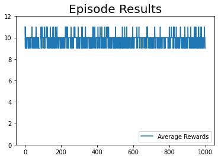

```python
# Visualise the results of testing the policy.
#These results are from each episode, run over 1000 iterations.
plt.plot(metrics['Episode'], metrics['Average'], label="Average Rewards")
plt.title('Episode Results', fontsize=20)
plt.legend(loc=4)
plt.ylim(0, 12)
plt.show()
```

# 6. Applying the Exact Policy to the CartPole-v0 Environment

```python
#Create animation utility for the solution
def agentanimation(agent, env, numberofframes=100):
  s = env.reset() #Reset the environment
  fig, axes = plt.subplots(1, 2, figsize=(10, 5)) #Setup graphing
  img = axes[0].imshow(env.render(mode='rgb_array')) #Setup frames
  frames = [env.render(mode='rgb_array')] #Setup frames
  returns = [0]
  env_active = True #Make the environment active

  #Step through the solution and capture frames
  for step in range(numberofframes):
    a = agent(s)
    s, r, done, _ = env.step(a)
    frames.append(env.render(mode='rgb_array'))
    returns.append(r + returns[-1])
    #When finished, turn off the environment and print results
    if env_active and done:
      env_active = False
      print(f'Game finished! The agent lasted {step} steps.')
  #Define plotting parameters
  axes[1].set_title('Cumulative returns', fontsize=20)
  axes[1].set_xlim(0, numberofframes)
  axes[1].set_ylim(0, max(returns) * 1.2)
  line, = axes[1].plot([], [], lw=2)

  #Display the frames captured
  def init():
    line.set_data([], [])
    img.set_data(frames[0])
    return [img]

  #Sequence the frames to create animation
  def animate(i):
    line.set_data(np.arange(i), returns[:i])
    img.set_data(frames[i])
    return [img]

  #Create the animation variable holding all configured parameters
  anim = animation.FuncAnimation(fig, animate, init_func=init, frames=numberofframes, interval=50)
  plt.close()
  #Return the animation file
  return HTML(anim.to_jshtml())
```

Defining the exact policy as a function.

```python
#Apply the policy using pole angle (theta) and rotation rate (theta_dot)
def exact_policy(obs):
  theta, theta_dot = obs[2:4]
  if abs(theta) < 0.03:
    if theta_dot < 0:
      action = 0 #left
    else:
      action = 1 #right
  else:
    if theta < 0:
      action = 0 #left
    else:
      action = 1 #right
  #Return the action the agent will apply
  return action
```

Animating the solution

```python
#Animate the exact policy and observe cumulative returns
agentanimation(exact_policy, env, numberofframes=50)
```

[figure not shown]

Once Loop Reflect

Finalise the solution and verify results.

```python
#Define a utility function to auto-test the exact policy
Number_of_scenarios = 1000 #Set iterations
Maximum_actions_taken = 500 #Set actions

def verifypolicy(policyfuncion, scenario_n = Number_of_scenarios, maximum_actions = Maximum_actions_taken, verbose=False):
    final_rewards = [] #Store the rewards
    #Loop for the number of scenarios defined
    for episode in range(scenario_n):
        if verbose and episode % 50 == 0:
            print(episode)
        episode_rewards = 0
        obs = env.reset()  # reset environment to a random position
        #Loop for the number of max actions defined, run the input policy
        for step in range(maximum_actions):
            action = policyfuncion(obs)
            obs, reward, done, info = env.step(action)
            episode_rewards += reward
            if done:
                break
        final_rewards.append(episode_rewards) #Add on the rewards from each run
    return final_rewards
```

```python
#Define a utility function to visualise the exact policy
def visualisepolicy(finalrewards, policyname:str=''):
    #Create a plot to show the final rewards
    fig = plt.plot(range(len(finalrewards)), finalrewards)
    plt.grid()
    plt.title(policyname + " Mean Reward {:.2f}, Std Reward {:.2f}".format(np.mean(finalrewards), np.min(finalrewards)))
    plt.ylabel('Cumulative Reward')
    plt.xlabel('Steps')
    plt.ylim(0, max(finalrewards)*1.1)
    return fig
```

```python
#Run the exact policy through the test function
exact_policy_rewards = verifypolicy(exact_policy, maximum_actions=510)
```

[figure not shown]

```python
#Visualise the exact policy and observe average rewards over 1000 iterations
visualisepolicy(exact_policy_rewards, "Exact Policy for CartPole-v0")
```

**Markov Decision Process (MDP)**

```python
# state names for use in building a MDP
states = [
      'Theta',
      'y',
      'theta_dot',
      'y_dot'
    ]
# action names for use in building a MDP
actions = ['Left','Right']
# Define the known discrete mdp environment
# Define our transition probabilities with respect to stochasticity
transition_probs = {
        'Theta': {
            'Left': { 'Theta': 0.7, 'y': 0.3},
            'Right': { 'theta_dot': 0.9, 'y_dot': 0.1}
        },
        'y': {
            'Left': { 'Theta': 0.2, 'y': 0.8},
            'Right': { 'y_dot': 0.7, 'theta_dot': 0.3}
        },
        'theta_dot': {
            'Left': { 'theta_dot': 0.9, 'y_dot': 0.1},
            'Right': { 'Theta': 0.9, 'y': 0.1}
        },
        'y_dot': {
            'Left': { 'y_dot': 0.7, 'theta_dot': 0.3 },
            'Right': { 'y': 0.6, 'Theta': 0.4 }
        }
    }
# Define the rewards
rewards = {
        'Theta': {
            'Left': { 'Theta': +1, 'y': 0},
            'Right': { 'theta_dot': +1, 'y_dot': 0}
        },
        'y': {
            'Left': { 'Theta': +1, 'y': 0},
            'Right': { 'y_dot': +1, 'theta_dot': 0}
        },
        'theta_dot': {
            'Left': { 'theta_dot': +1, 'y_dot': 0},
            'Right': { 'Theta': +1, 'y': 0}
        },
        'y_dot': {
            'Left': { 'y_dot': +1, 'theta_dot': 0},
            'Right': { 'y': +1, 'Theta': 0}
        }
    }
```

```python
#Code reused from SIT796 Week 3 Workshop.
from google.colab import drive
drive.mount('/content/drive')
sys.path.insert(0,'/content/drive/MyDrive/Uni Assignments/SIT796 Reinforcement Learning/Task 3')

from mdp import has_graphviz
# if we dont have graphvizualization support
# then we don't need to run this cell
if has_graphviz:

  from mdp import MDP
  from mdp import plot_graph, plot_graph_with_state_values, plot_graph_optimal_strategy_and_state_values
  mdp = MDP(transition_probs, rewards, initial_state='Theta')
```

```python
#Visualise the markov chain graph for CartPole
graph = plot_graph(mdp)
# Save as svg file
graph.format = 'png'
graph.view(filename='SIT796_Task3_1D_MDP', directory='./')
```

```
'SIT796_Task3_1D_MDP.png'
```

[figure not shown]

```python
#plot the markov chain visual here
MDP_plot = cv2.imread('SIT796_Task3_1D_MDP.png',1)
plt.imshow(MDP_plot)
plt.axis("off")
plt.show()
```

# References

This notebook borrows the ideas of the following authors and their contributions:

[1] J. Furby (2019) CartPole-v0 [Source Code] https://github.com/JackFurby/CartPole-v0/blob/master/cartPole.py

[2] J. Xu (2021) How to Beat the CartPole Game in 5 Lines - A simple solution without Artificial Intelligence [Source Code] https://towardsdatascience.com/how-to-beat-the-cartpole-game-in-5-lines-5ab4e738c93f

[3] J. Muiruri (2022) CartPole Skating [Source Code] https://github.com/microsoft/ML-For-Beginners/blob/main/8-Reinforcement/2-Gym/README.md

```python
!jupyter nbconvert SIT796_Task_3_1D_final.ipynb --to pdf
```

[output not shown]